# Cell-Cell Interaction between ‘FCGR3A Mono (sender cells)’ vs ‘Memory CD4 T (receiver cells)’

Pranay Jain

2025-07-22

# Prepare NicheNet analysis

### Load packages

```r
if(!requireNamespace("devtools", quietly = TRUE)) {
  install.packages("devtools")
}

library(nichenetr)
library(Seurat)
library(SeuratObject)
library(tidyverse)
library(dplyr)
```

### Read in the expression data of interacting cells

We processed and aggregated the original dataset by using the Seurat alignment pipeline. As we created this object using Seurat v3, it has to be updated with `UpdateSeuratObject`. Note that genes should be named by their official mouse/human gene symbol.

```r
seuratObj <- readRDS("../pbmc_tutorial.rds")

seuratObj@meta.data %>% head()
```

```
##                  orig.ident nCount_RNA nFeature_RNA percent.mt RNA_snn_res.0.5
## AAACATACAACCAC-1     pbmc3k       2419          779  3.0177759               0
## AAACATTGAGCTAC-1     pbmc3k       4903         1352  3.7935958               3
## AAACATTGATCAGC-1     pbmc3k       3147         1129  0.8897363               2
## AAACCGTGCTTCCG-1     pbmc3k       2639          960  1.7430845               1
## AAACCGTGTATGCG-1     pbmc3k        980          521  1.2244898               6
## AAACGCACTGGTAC-1     pbmc3k       2163          781  1.6643551               2
##                  seurat_clusters    cell_type
## AAACATACAACCAC-1               0  Naive CD4 T
## AAACATTGAGCTAC-1               3            B
## AAACATTGATCAGC-1               2 Memory CD4 T
## AAACCGTGCTTCCG-1               1   CD14+ Mono
## AAACCGTGTATGCG-1               6           NK
## AAACGCACTGGTAC-1               2 Memory CD4 T
```

```r
# For older Seurat objects, you may need to run this
seuratObj <- UpdateSeuratObject(seuratObj)
```

Additionally, if your expression data has the older gene symbols, you may want to use our alias conversion function to avoid the loss of gene names.

```r
seuratObj <- nichenetr:::alias_to_symbol_seurat(seuratObj, "human")
```

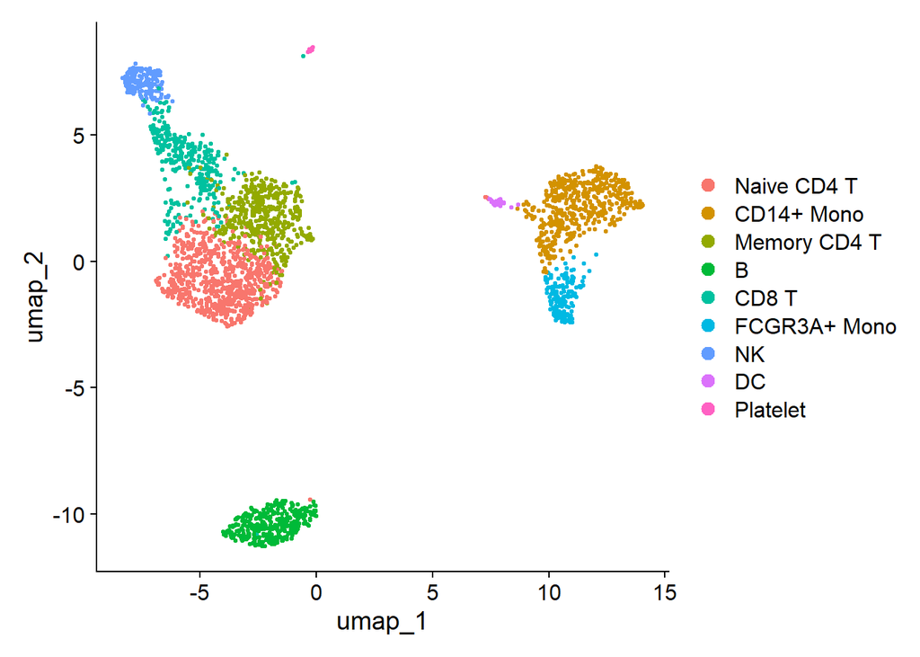

```r
# Note that the number of cells of some cell types is very low and should preferably be higher for a real application
seuratObj@meta.data$cell_type %>% table()
## .
##  Naive CD4 T   CD14+ Mono Memory CD4 T            B        CD8 T FCGR3A+ Mono
##          692          483          449          342          313          159
##           NK           DC     Platelet
##          154           32           14

DimPlot(seuratObj, reduction = "umap")
```

### Read in NicheNet’s networks

The ligand-target prior model, ligand-receptor network, and weighted integrated networks are needed for this vignette. The ligand-target prior model is a matrix describing the potential that a ligand may regulate a target gene, and it is used to run the ligand activity analysis. The ligand-receptor network contains information on potential ligand-receptor bindings, and it is used to identify potential ligands. Finally, the weighted ligand-receptor network contains weights representing the potential that a ligand will bind to a receptor, and it is used for visualization.

```r
organism <- "human"

if(organism == "human"){
  lr_network <- readRDS(url("https://zenodo.org/record/7074291/files/lr_network_human_21122021.rds"))
  ligand_target_matrix <- readRDS(url("https://zenodo.org/record/7074291/files/ligand_target_matrix_nsga2r_final.rds"))
  weighted_networks <- readRDS(url("https://zenodo.org/record/7074291/files/weighted_networks_nsga2r_final.rds"))
} else if(organism == "mouse"){
  lr_network <- readRDS(url("https://zenodo.org/record/7074291/files/lr_network_mouse_21122021.rds"))
  ligand_target_matrix <- readRDS(url("https://zenodo.org/record/7074291/files/ligand_target_matrix_nsga2r_final_mouse.rds"))
  weighted_networks <- readRDS(url("https://zenodo.org/record/7074291/files/weighted_networks_nsga2r_final_mouse.rds"))

}

lr_network <- lr_network %>% distinct(from, to)
head(lr_network)
```

```
## # A tibble: 6 × 2
##   from  to
##   <chr> <chr>
## 1 A2M   MMP2
## 2 A2M   MMP9
## 3 A2M   LRP1
## 4 A2M   KLK3
## 5 AANAT MTNR1A
## 6 AANAT MTNR1B
```

```r
ligand_target_matrix[1:5,1:5] # target genes in rows, ligands in columns
```

```
##                     A2M        AANAT        ABCA1          ACE        ACE2
## A-GAMMA3'E 0.0000000000 0.0000000000 0.0000000000 0.0000000000 0.000000000
## A1BG       0.0018503922 0.0011108718 0.0014225077 0.0028594037 0.001139013
## A1BG-AS1   0.0007400797 0.0004677614 0.0005193137 0.0007836698 0.000375007
## A1CF       0.0024799266 0.0013026348 0.0020420890 0.0047921048 0.003273375
## A2M        0.0084693452 0.0040689323 0.0064256379 0.0105191365 0.005719199
```

```r
head(weighted_networks$lr_sig) # interactions and their weights in the ligand-receptor + signaling network
```

```
## # A tibble: 6 × 3
##   from       to         weight
##   <chr>      <chr>       <dbl>
## 1 A-GAMMA3'E ACTG1P11   0.100
## 2 A-GAMMA3'E AXIN2      0.0869
## 3 A-GAMMA3'E BUB1B-PAK6 0.0932
## 4 A-GAMMA3'E CEACAM7    0.0793
## 5 A-GAMMA3'E CHRNA1     0.0901
## 6 A-GAMMA3'E DTX2P1     0.0976
```

```r
head(weighted_networks$gr) # interactions and their weights in the gene regulatory network
```

```
## # A tibble: 6 × 3
##   from  to     weight
##   <chr> <chr>   <dbl>
## 1 A1BG  A2M    0.165
## 2 AAAS  GFAP   0.0906
## 3 AADAC CTAG1B 0.104
## 4 AADAC CYP3A4 0.177
## 5 AADAC DIRAS3 0.0936
## 6 AADAC IRF8   0.0892
```

# Perform the NicheNet analysis

## 1. Define a set of potential ligands for both the sender-agnostic and sender-focused approach

We first define a “receiver/target” cell population and determine which genes are expressed. Here, we will consider a gene to be expressed if it is expressed in at least 5% of cells (by default this is set to 10%). The receiver cell population can only consist of one cell type, so in case of multiple receiver populations, you will have to rerun the vignette separately for each one. We will only look at Memory CD4 T cells in this vignette.

```r
receiver = "Memory CD4 T"
expressed_genes_receiver <- get_expressed_genes(receiver, seuratObj, pct = 0.05)
```

Get a list of all receptors available in the ligand-receptor network, and define expressed receptors as genes that are in the ligand-receptor network and expressed in the receiver. Then, define the potential ligands as all ligands whose cognate receptors are expressed.

```r
all_receptors <- unique(lr_network$to)
expressed_receptors <- intersect(all_receptors, expressed_genes_receiver)

potential_ligands <- lr_network %>% filter(to %in% expressed_receptors) %>% pull(from) %>% unique()
```

```r
sender_celltypes <- c("FCGR3A+ Mono")

# Use lapply to get the expressed genes of every sender cell type separately here
list_expressed_genes_sender <- sender_celltypes %>% unique() %>% lapply(get_expressed_genes, seuratObj, 0.05)
expressed_genes_sender <- list_expressed_genes_sender %>% unlist() %>% unique()

potential_ligands_focused <- intersect(potential_ligands, expressed_genes_sender)

# Also check
length(expressed_genes_sender)
```

```
## [1] 5031
```

```r
length(potential_ligands)
```

```
## [1] 442
```

```r
length(potential_ligands_focused)
```

```
## [1] 77
```

## 2. Define the gene set of interest

```r
DE_table_receiver <-  FindMarkers(object = seuratObj,
                                  ident.1 = receiver, ident.2 = sender_celltypes,
                                  min.pct = 0.05) %>% rownames_to_column("gene")

geneset_oi <- DE_table_receiver %>% filter(p_val_adj <= 0.05 & abs(avg_log2FC) >= 0.25) %>% pull(gene)
geneset_oi <- geneset_oi %>% .[. %in% rownames(ligand_target_matrix)]
```

## 3. Define the background genes

All expressed genes in the receiver cell population (that are also in the ligand-target matrix) is defined as the ‘background set’ for our ligand prioritization procedure in the next step. It’s also important to check that the number of background genes is a ‘reasonable’ number, generally between 5000-10000, and sufficiently larger than our gene set of interest.

```r
background_expressed_genes <- expressed_genes_receiver %>% .[. %in% rownames(ligand_target_matrix)]

length(background_expressed_genes)
```

```
## [1] 3828
```

```r
length(geneset_oi)
```

```
## [1] 949
```

## 4. Perform NicheNet ligand activity analysis

Ligands are ranked based on the area under the precision-recall curve (AUPR) between a ligand’s target predictions and the observed transcriptional response. Although other metrics like the AUROC and pearson correlation coefficient are also computed, we demonstrated in our validation study that the AUPR was the most informative measure to define ligand activity (this was the Pearson correlation for v1). The vignette on how we performed the validation can be found at Evaluation of NicheNet’s ligand-target predictions.

We will first show the results of the sender-agnostic approach.

```r
ligand_activities <- predict_ligand_activities(geneset = geneset_oi,
                                               background_expressed_genes = background_expressed_genes,
                                               ligand_target_matrix = ligand_target_matrix,
                                               potential_ligands = potential_ligands)

ligand_activities <- ligand_activities %>% arrange(-aupr_corrected) %>% mutate(rank = rank(desc(aupr_corrected)))
ligand_activities
```

```
## # A tibble: 442 × 6
##    test_ligand auroc  aupr aupr_corrected pearson  rank
##    <chr>       <dbl> <dbl>          <dbl>   <dbl> <dbl>
##  1 IGFL3       0.5   0.613         0.387   NA         1
##  2 IL4         0.623 0.370         0.144    0.242     2
##  3 IL10        0.600 0.341         0.116    0.202     3
##  4 TGFB1       0.600 0.334         0.108    0.182     4
##  5 TNF         0.611 0.331         0.105    0.164     5
##  6 IFNG        0.610 0.326         0.100    0.160     6
##  7 JAM2        0.602 0.320         0.0939   0.159     7
##  8 IL36G       0.580 0.317         0.0908   0.139     8
##  9 PF4         0.580 0.315         0.0898   0.118     9
## 10 IL13        0.577 0.315         0.0889   0.154    10
## # ℹ 432 more rows
```

We will use the top 30 ligands to predict active target genes and construct an active ligand-receptor network. However, the choice of looking only at the 30 top-ranked ligands for further biological interpretation is based on biological intuition and is quite arbitrary. Therefore, users can decide to continue the analysis with a different number of ligands. We recommend to check the selected cutoff by looking at the distribution of the ligand activity values. Here, we show the ligand activity histogram (the score for the 30th ligand is indicated via the dashed line).

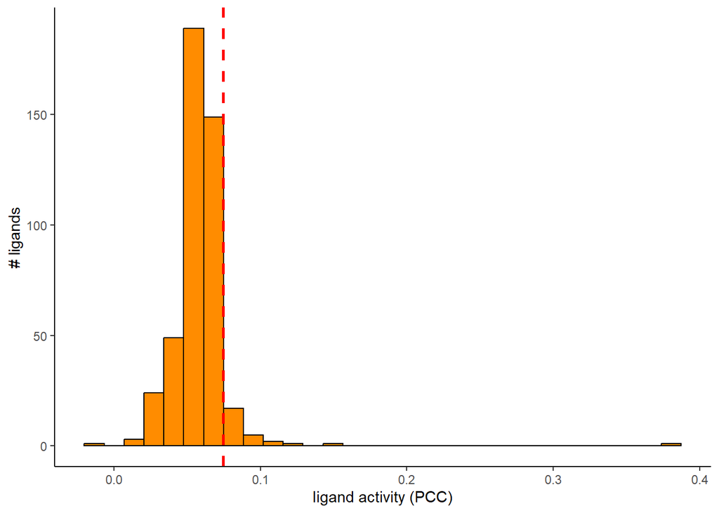

```r
p_hist_lig_activity <- ggplot(ligand_activities, aes(x=aupr_corrected)) +
  geom_histogram(color="black", fill="darkorange")  +
  geom_vline(aes(xintercept=min(ligand_activities %>% top_n(30, aupr_corrected) %>% pull(aupr_corrected))),
             color="red", linetype="dashed", size=1) +
  labs(x="ligand activity (PCC)", y = "# ligands") +
  theme_classic()

p_hist_lig_activity
```

```r
best_upstream_ligands <- ligand_activities %>% top_n(30, aupr_corrected) %>% arrange(-aupr_corrected) %>% pull(test_ligand)
```

We can also visualize the ligand activity measure (AUPR) of these top-ranked ligands:

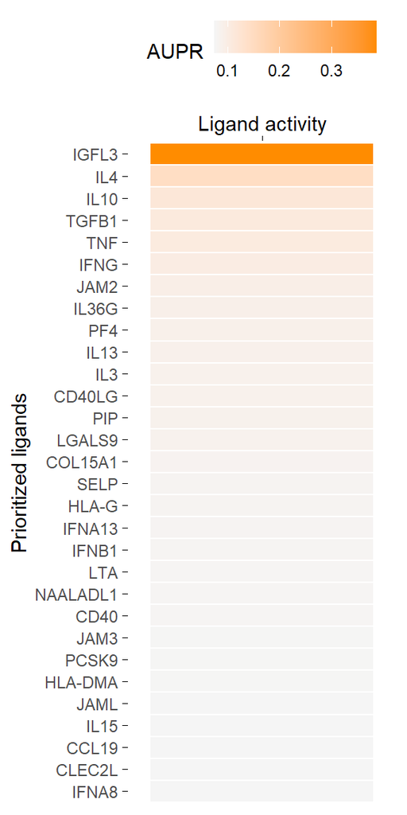

```r
vis_ligand_aupr <- ligand_activities %>% filter(test_ligand %in% best_upstream_ligands) %>%
  column_to_rownames("test_ligand") %>% select(aupr_corrected) %>% arrange(aupr_corrected) %>% as.matrix(ncol = 1)

(make_heatmap_ggplot(vis_ligand_aupr,
                     "Prioritized ligands", "Ligand activity",
                     legend_title = "AUPR", color = "darkorange") +
    theme(axis.text.x.top = element_blank()))
```

## 5. Infer target genes and receptors of top-ranked ligands

### Active target gene inference

Active target genes are defined as genes in the gene set of interest that have the highest regulatory potential for each top-ranked ligand. These top targets of each ligand are based on the prior model. The function get_weighted_ligand_target_links will return genes that are in the gene set of interest and are the top `n` targets of a ligand (default: `n = 200`, but there are too many target genes here so we only considered the top 100).

```r
active_ligand_target_links_df <- best_upstream_ligands %>%
  lapply(get_weighted_ligand_target_links,
         geneset = geneset_oi,
         ligand_target_matrix = ligand_target_matrix,
         n = 100) %>%
  bind_rows() %>% drop_na()

nrow(active_ligand_target_links_df)
```

```
## [1] 1529
```

```r
head(active_ligand_target_links_df)
```

```
## # A tibble: 6 × 3
##   ligand target  weight
##   <chr>  <chr>    <dbl>
## 1 IGFL3  AAK1         0
## 2 IGFL3  ABHD14A      0
## 3 IGFL3  ABHD5        0
## 4 IGFL3  ABI3         0
## 5 IGFL3  ACAA1        0
## 6 IGFL3  ACAP1        0
```

For visualization purposes, the ligand-target prior model was adapted by setting a regulatory potential score to 0 if their score was below a predefined cutoff (default: 0.25, or the 25th percentile) across all scores between the top-ranked ligands and their top `n` targets. We recommend users to test several cutoff values for the best visualization, as lowering or increasing the cutoff will result in a denser or sparser heatmap, respectively.

```r
active_ligand_target_links <- prepare_ligand_target_visualization(
  ligand_target_df = active_ligand_target_links_df,
  ligand_target_matrix = ligand_target_matrix,
  cutoff = 0.95)

nrow(active_ligand_target_links)
```

```
## [1] 57
```

```r
head(active_ligand_target_links)
```

```
##          IL15 IL4 IL3 IL10      IFNG IFNB1 TGFB1 IL36G TNF IL13
## HLA-A       0   0   0    0 0.2543128     0     0     0   0    0
## HLA-DRA     0   0   0    0 0.2171043     0     0     0   0    0
## TNFSF10     0   0   0    0 0.2134719     0     0     0   0    0
## DYNLT1      0   0   0    0 0.1961973     0     0     0   0    0
## KLF4        0   0   0    0 0.2091727     0     0     0   0    0
## HLA-DPA1    0   0   0    0 0.2624038     0     0     0   0    0
```

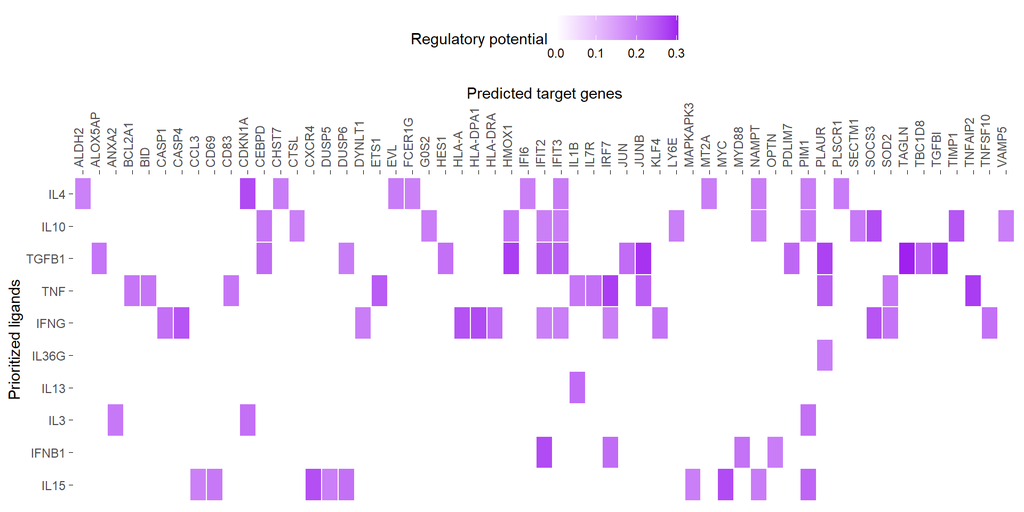

```r
order_ligands <- intersect(best_upstream_ligands, colnames(active_ligand_target_links)) %>% rev()
order_targets <- active_ligand_target_links_df$target %>% unique() %>% intersect(rownames(active_ligand_target_links))

vis_ligand_target <- t(active_ligand_target_links[order_targets,order_ligands])

make_heatmap_ggplot(vis_ligand_target, "Prioritized ligands", "Predicted target genes",
                    color = "purple", legend_title = "Regulatory potential") +
  scale_fill_gradient2(low = "whitesmoke",  high = "purple")
```

### Receptors of top-ranked ligands

Similar to above, we identify which receptors have the highest interaction potential with the top-ranked ligands.

```r
ligand_receptor_links_df <- get_weighted_ligand_receptor_links(
  best_upstream_ligands, expressed_receptors,
  lr_network, weighted_networks$lr_sig)
```

Then, we create a heatmap for ligand-receptor interactions. Here, both the ligands and receptors are ordered by hierarchical clustering You can choose to order only ligands or receptors hierarachically (with `order_hclust = ligands` or `receptors`, respectively) or not at all (`none`), in which case the ligands are ordered based on their rankings, and the receptors are ordered alphabetically..

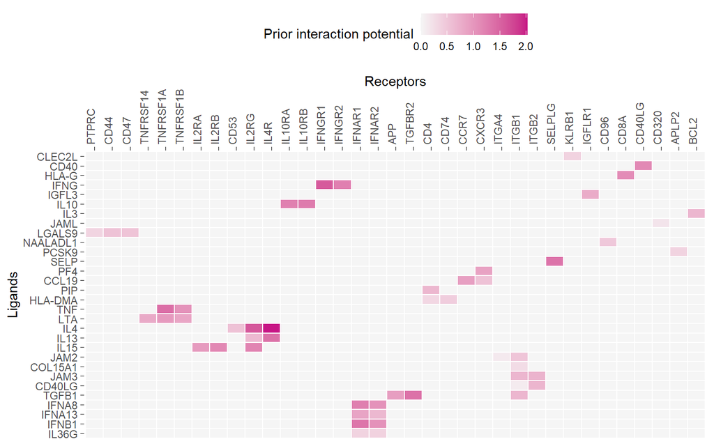

```r
vis_ligand_receptor_network <- prepare_ligand_receptor_visualization(
  ligand_receptor_links_df,
  best_upstream_ligands,
  order_hclust = "both")

(make_heatmap_ggplot(t(vis_ligand_receptor_network),
                     y_name = "Ligands", x_name = "Receptors",
                     color = "mediumvioletred", legend_title = "Prior interaction potential"))
```